# Разведывательный анализ данных

## Выбор регионов, лидирующих по потребительской активности, безналичным платежам и внутреннему туризму

Загрузка данных

1. Выведем описательные статистики для данных из СберИндекс

```r
summary(df$Индекс.БП)
```

```
##    Min. 1st Qu.  Median    Mean 3rd Qu.    Max.
##    9.40   49.20   53.40   51.71   57.10   71.10
```

```r
summary(df$Индекс.ПА)
```

```
##    Min. 1st Qu.  Median    Mean 3rd Qu.    Max.
##   34.00   61.00   67.00   65.43   71.00   88.00
```

```r
summary(df$Количество.ВТ)
```

```
##    Min. 1st Qu.  Median    Mean 3rd Qu.    Max.
## -85.470 -28.052  -5.125  -8.061  11.162  86.140
```

Согласно описательным статистикам видно, что: - индекс безналичных платежей в среднем по стране равен, чуть больше 50% (52%), но в некоторых регионах он возрастает до 70% и может упасть до 10%. Это значит, что в некоторых регионах люди очень мало используют безналичный способ оплаты (возможно такой способ оплаты недоступен), а в некоторых очень активно, но в среднем по стране чуть больше половины людей производит оплату безналичным способом. - Индекс потребительской активности в среднем равен 65%, значит что потребители в среднем покупают товаров на 65% от самого активного дня в году (30 декабря), что думаю неплохо. Также есть месяца когда индекс потребительской активности возрастает до 88% и падает до 34%. - Что касается количества внутренних туристов, то среднее количество равно примерно минус 8%, знак минус говорит о том что в среднем количество туристов уменьшилось по сравнению с предыдущим годом.

2. Построим графики для показателей СберИндекс в среднем по России, по месяцам. Для этого создадим дополнительный датафрейм с данными по месяцам в среднем по России.

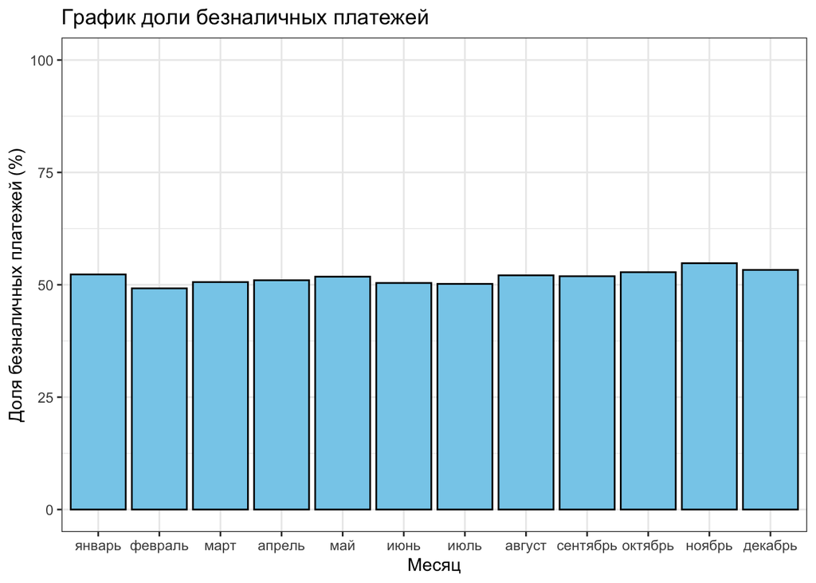

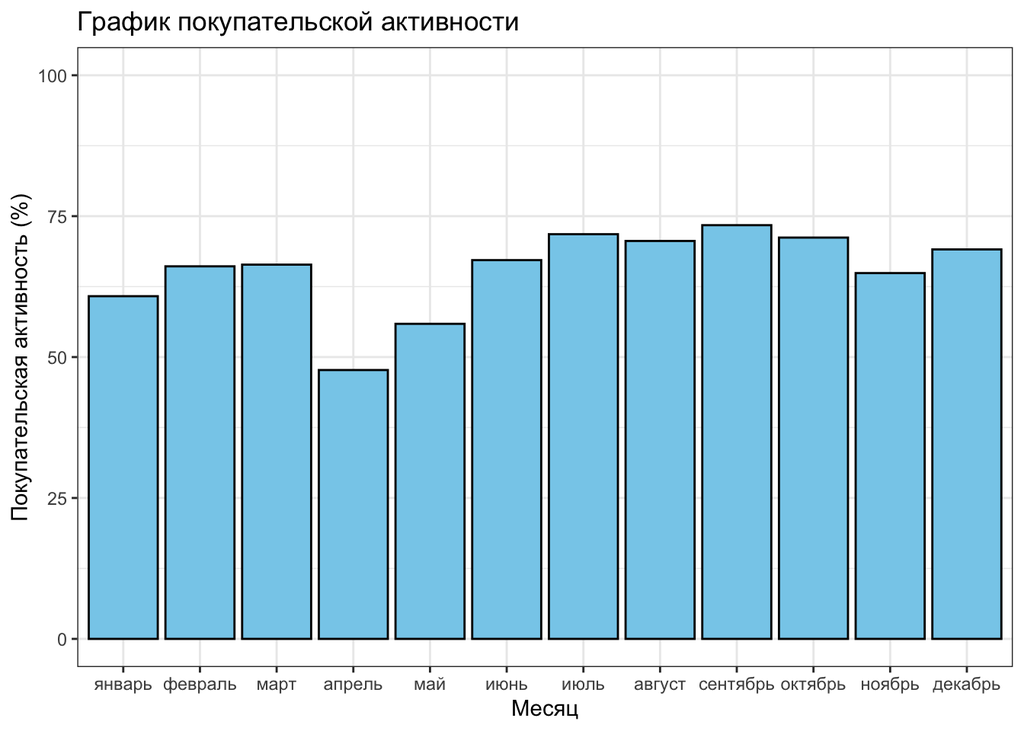

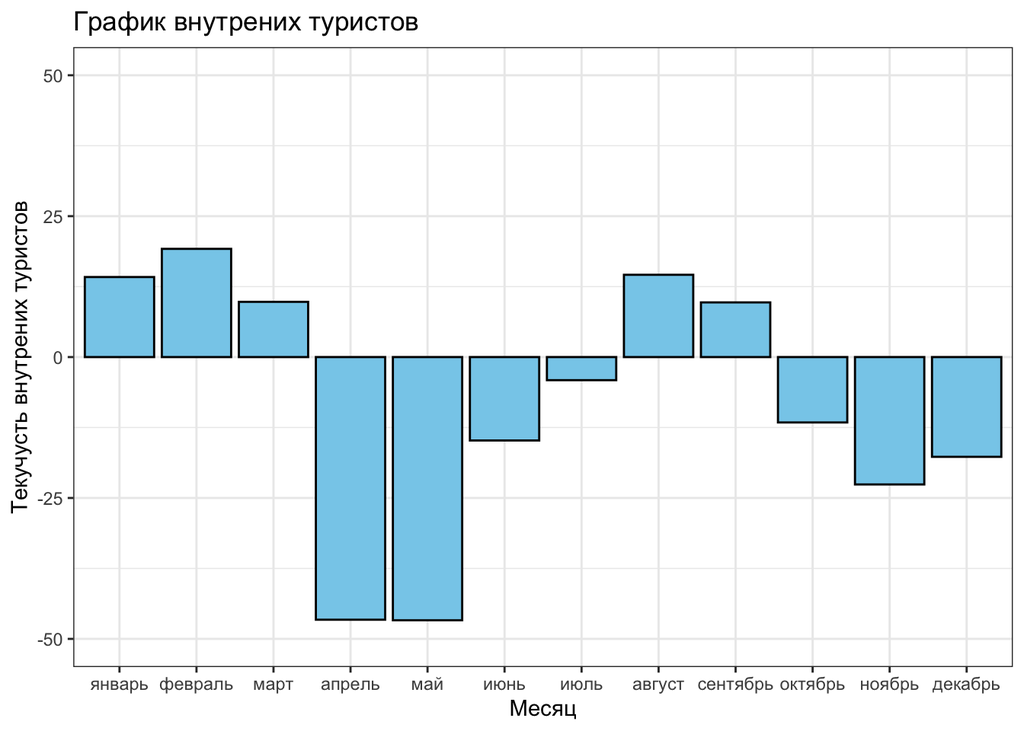

- График доли безналичных платежей в среднем по России показывает, что люди каждый месяц оплачивают безналичным способом чуть больше половины всех покупок. - График покупательской способности показывает, что у людей покупательская активность падает в апреле и мая. Наилучшие месяцы по покупательской активности это начиная с июля и почти до конца года. - Что касается графика движения внутренних туристов, то очень сильно просел этот показатель в апреле и мая по сравнению с предыдущим годом, также спад наблюдается и на конец года. Но начало года показало увеличения количества внутрених туристов. Так же конец лето и начало осень идет увеличения притока внутренних туристов.

3 .Построим графики boxplot для показателей СберИндекс.

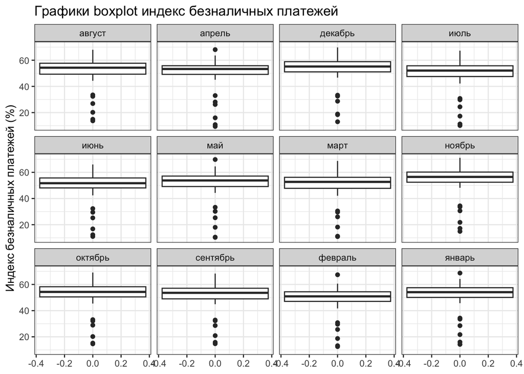

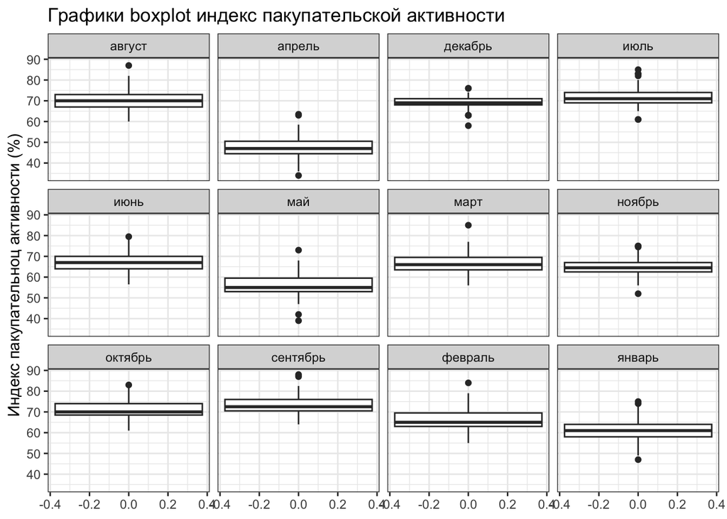

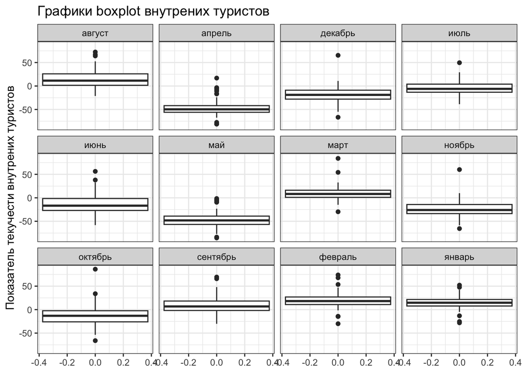

4. Выведим нетипичные значения в отдельные датафреймы, соответственно по показателям СберИндекса.

| Регион | Год | Месяц | Квартал | Число абонентов | Среднемесячная з.п. | Уровень безработицы | Индекс.БП | Индекс.ПА | Количество.ВТ | Всего одобренных заявок | Онлайн-заявки | Офлайн-заявки | Всего ипотечных сделок | Доля сделок, первичка | Доля сделок, вторичка |
| --- | --- | --- | --- | --- | --- | --- | --- | --- | --- | --- | --- | --- | --- | --- | --- |
| астраханская область | 2020 | апрель | квартал 2 | 745 | 35800.4 | 7.9 | 48.6 | 45.0 | -67.45 | 100 - 500 | 0.55 | 0.45 | 100 - 500 | 0.05 | 0.94 |
| белгородская область | 2020 | сентябрь | квартал 3 | 15804 | 36500.8 | 5.2 | 52.3 | 87.0 | 6.54 | 1 000 - 5 000 | 0.35 | 0.65 | 500 - 1 000 | 0.12 | 0.85 |
| вологодская область | 2020 | апрель | квартал 2 | 2230 | 40288.4 | 6.5 | 58.1 | 44.0 | -54.95 | 500 - 1 000 | 0.39 | 0.61 | 100 - 500 | 0.12 | 0.86 |
| воронежская область | 2020 | сентябрь | квартал 3 | 5901 | 35744.5 | 4.6 | 54.3 | 88.0 | 13.60 | 1 000 - 5 000 | 0.30 | 0.70 | > 1 000 | 0.35 | 0.63 |
| ивановская область | 2020 | апрель | квартал 2 | 2518 | 26770.2 | 5.9 | 48.9 | 42.5 | -51.80 | 100 - 500 | 0.53 | 0.47 | 100 - 500 | 0.05 | 0.90 |
| кабардино-балкарская республика | 2020 | апрель | квартал 2 | 60 | 28005.8 | 16.0 | 26.2 | 43.5 | -50.34 | 100 - 500 | 0.43 | 0.57 | 100 - 500 | 0.08 | 0.87 |
| калининградская область | 2020 | август | квартал 3 | 828 | 36102.0 | 7.5 | 59.0 | 87.0 | 67.13 | 1 000 - 5 000 | 0.44 | 0.56 | 500 - 1 000 | 0.44 | 0.54 |
| калининградская область | 2020 | сентябрь | квартал 3 | 828 | 36257.7 | 7.4 | 58.7 | 87.5 | 65.84 | 1 000 - 5 000 | 0.43 | 0.57 | 500 - 1 000 | 0.39 | 0.57 |
| костромская область | 2020 | апрель | квартал 2 | 30 | 28995.0 | 6.0 | 55.1 | 43.0 | -43.83 | 100 - 500 | 0.36 | 0.64 | 100 - 500 | 0.10 | 0.89 |
| краснодарский край | 2020 | апрель | квартал 2 | 10206 | 36884.8 | 6.4 | 49.8 | 43.0 | -67.22 | 1 000 - 5 000 | 0.50 | 0.50 | > 1 000 | 0.19 | 0.78 |

[output cut: 26 more lines]

| Регион | Год | Месяц | Квартал | Число абонентов | Среднемесячная з.п. | Уровень безработицы | Индекс.БП | Индекс.ПА | Количество.ВТ | Всего одобренных заявок | Онлайн-заявки | Офлайн-заявки | Всего ипотечных сделок | Доля сделок, первичка | Доля сделок, вторичка |
| --- | --- | --- | --- | --- | --- | --- | --- | --- | --- | --- | --- | --- | --- | --- | --- |
| кабардино-балкарская республика | 2020 | январь | квартал 1 | 57 | 27758.5 | 11.6 | 28.5 | 52.0 | 24.01 | 100 - 500 | 0.23 | 0.77 | 50 - 100 | 0.12 | 0.81 |
| кабардино-балкарская республика | 2020 | февраль | квартал 1 | 57 | 27761.4 | 13.3 | 25.6 | 58.0 | 34.15 | 100 - 500 | 0.26 | 0.74 | 100 - 500 | 0.08 | 0.88 |
| кабардино-балкарская республика | 2020 | март | квартал 1 | 57 | 27045.3 | 15.0 | 26.0 | 60.0 | 10.87 | 100 - 500 | 0.22 | 0.78 | 100 - 500 | 0.12 | 0.85 |
| кабардино-балкарская республика | 2020 | апрель | квартал 2 | 60 | 28005.8 | 16.0 | 26.2 | 43.5 | -50.34 | 100 - 500 | 0.43 | 0.57 | 100 - 500 | 0.08 | 0.87 |
| кабардино-балкарская республика | 2020 | май | квартал 2 | 60 | 31535.9 | 15.8 | 25.3 | 47.0 | -58.07 | 100 - 500 | 0.34 | 0.66 | 100 - 500 | 0.19 | 0.74 |
| кабардино-балкарская республика | 2020 | июнь | квартал 2 | 60 | 35228.3 | 15.4 | 25.2 | 58.5 | -18.56 | 500 - 1 000 | 0.24 | 0.76 | 100 - 500 | 0.11 | 0.82 |
| кабардино-балкарская республика | 2020 | июль | квартал 3 | 65 | 27221.8 | 15.2 | 24.4 | 65.0 | -8.02 | 500 - 1 000 | 0.26 | 0.74 | 100 - 500 | 0.07 | 0.88 |
| кабардино-балкарская республика | 2020 | август | квартал 3 | 65 | 27088.6 | 15.4 | 26.9 | 66.0 | 28.23 | 500 - 1 000 | 0.22 | 0.78 | 100 - 500 | 0.08 | 0.87 |
| кабардино-балкарская республика | 2020 | сентябрь | квартал 3 | 65 | 28665.2 | 15.7 | 28.6 | 70.5 | 40.04 | 500 - 1 000 | 0.21 | 0.79 | 100 - 500 | 0.05 | 0.92 |
| кабардино-балкарская республика | 2020 | октябрь | квартал 4 | 71 | 29741.6 | 16.2 | 28.9 | 70.0 | 7.18 | 500 - 1 000 | 0.30 | 0.70 | 100 - 500 | 0.06 | 0.89 |

[output cut: 66 more lines]

| Регион | Год | Месяц | Квартал | Число абонентов | Среднемесячная з.п. | Уровень безработицы | Индекс.БП | Индекс.ПА | Количество.ВТ | Всего одобренных заявок | Онлайн-заявки | Офлайн-заявки | Всего ипотечных сделок | Доля сделок, первичка | Доля сделок, вторичка |
| --- | --- | --- | --- | --- | --- | --- | --- | --- | --- | --- | --- | --- | --- | --- | --- |
| владимирская область | 2020 | февраль | квартал 1 | 1437 | 32167.5 | 4.0 | 48.7 | 69 | 73.88 | 500 - 1 000 | 0.22 | 0.78 | 100 - 500 | 0.14 | 0.83 |
| владимирская область | 2020 | март | квартал 1 | 1437 | 33767.6 | 5.2 | 49.8 | 68 | 83.99 | 1 000 - 5 000 | 0.22 | 0.78 | 100 - 500 | 0.16 | 0.82 |
| владимирская область | 2020 | август | квартал 3 | 2275 | 32389.7 | 6.4 | 53.5 | 72 | 72.43 | 1 000 - 5 000 | 0.39 | 0.61 | 500 - 1 000 | 0.30 | 0.68 |
| владимирская область | 2020 | октябрь | квартал 4 | 2296 | 34610.6 | 5.7 | 53.6 | 73 | 86.14 | 1 000 - 5 000 | 0.40 | 0.60 | 500 - 1 000 | 0.21 | 0.74 |

После анализа датафрейма с нетипичными значениями можно предположить следующее: - В датафрейме с индексом безналичных платежей, видим, что к ним относятся большинство регионов Кавказа (причем в выборку попали регионы полностью по всем месяцам) и показатель всегда ниже первого квантиля. На мой взгляд не стоит относить эти значения к выбросам и удалять их, по следующим причинам: либо в этих регионах недостаточно развита система безналичных платежей, либо это связано с менталитетом местного населения, предпочитающих расплачиваться живыми деньгами. - В датафрейме с индексом покупательской активности, значения которые меньше первого квантиля приходятся на апрель и май. Если мы посмотрим на график покупательской активности, то увидим, что в эти месяца идет спад этого показателя. Можно предположить, что значения не являются выбросами удалять их также не стоит, а обусловлено спадом покупательной активности. То же самое и со значениями превышающие третий квантиль, выпадают на сентябрь месяц, что подтверждает график покупательской активности. - Значения в датафрейме количества внутренних туристов, тоже не стоит относить к выбросам, так как значения больше третьего квантиля и они приходятся на те месяца когда идет рост движения внутренних туристов, что подтверждает график количества внутренних туристов. Если говорить в целом нетипичные значения отличаются примерно на 1-5%, на мой взгляд не стоит удалять их. Они не повлияют на модель, а из-за их удаления можем потерять много полезной информации.

5. Выберем топ 30 регионов лидирующих по индексу покупательской способности

| Регион | Индекс.ПА |
| --- | --- |
| белгородская область | 76.7 |
| омская область | 76.0 |
| калининградская область | 74.8 |
| амурская область | 73.4 |
| воронежская область | 73.4 |
| тюменская область | 73.2 |
| хабаровский край | 71.0 |
| кировская область | 70.3 |
| алтайский край | 70.0 |
| тверская область | 69.5 |

[output cut: 20 more lines]

6. Выберем топ 30 регионов лидирующих по индексу безналичных платежей.

| Регион | Индекс.БП |
| --- | --- |
| ненецкий ао | 68.5 |
| мурманская область | 63.1 |
| республика карелия | 63.1 |
| республика коми | 62.5 |
| архангельская область | 61.0 |
| республика саха (якутия) | 60.9 |
| камчатский край | 60.4 |
| тюменская область | 60.0 |
| чукотский ао | 60.0 |
| санкт-петербург | 59.5 |

[output cut: 20 more lines]

7. Выберем те регионы которые лидируют по индексу покупательской способности и индексу безналичных платежей.

   | Регион | Индекс.БП | Индекс.ПА |
   | --- | --- | --- |
   | камчатский край | 60.4 | 67.3 |
   | тюменская область | 60.0 | 73.2 |
   | томская область | 59.0 | 66.5 |
   | калининградская область | 58.9 | 74.8 |
   | кировская область | 57.7 | 70.3 |
   | хабаровский край | 57.7 | 71.0 |
   | удмуртская республика | 57.4 | 66.4 |
   | свердловская область | 57.3 | 68.1 |
   | москва | 57.1 | 67.7 |
   | иркутская область | 56.6 | 68.5 |

   [output cut: 3 more lines]

8. Выберем строки из датафрейма df которые соответствуют выборки лидирующих регионов

   | Регион | Год | Месяц | Квартал | Число абонентов | Среднемесячная з.п. | Уровень безработицы | Индекс.БП | Индекс.ПА | Количество.ВТ | Всего одобренных заявок | Онлайн-заявки | Офлайн-заявки | Всего ипотечных сделок | Доля сделок, первичка | Доля сделок, вторичка |
   | --- | --- | --- | --- | --- | --- | --- | --- | --- | --- | --- | --- | --- | --- | --- | --- |
   | иркутская область | 2020 | январь | квартал 1 | 27074 | 45333.6 | 6.9 | 56.7 | 65.0 | 8.01 | 1 000 - 5 000 | 0.37 | 0.63 | 500 - 1 000 | 0.13 | 0.85 |
   | иркутская область | 2020 | февраль | квартал 1 | 27074 | 44975.0 | 7.5 | 54.0 | 70.0 | 11.71 | 1 000 - 5 000 | 0.36 | 0.64 | 500 - 1 000 | 0.12 | 0.86 |
   | иркутская область | 2020 | март | квартал 1 | 27074 | 48670.0 | 8.2 | 55.8 | 70.0 | -1.04 | 1 000 - 5 000 | 0.36 | 0.64 | > 1 000 | 0.12 | 0.86 |
   | иркутская область | 2020 | апрель | квартал 2 | 26349 | 48365.9 | 8.3 | 54.9 | 56.0 | -57.42 | 1 000 - 5 000 | 0.52 | 0.48 | > 1 000 | 0.07 | 0.91 |
   | иркутская область | 2020 | май | квартал 2 | 26349 | 52155.8 | 7.9 | 57.1 | 62.0 | -55.97 | 1 000 - 5 000 | 0.48 | 0.52 | 500 - 1 000 | 0.18 | 0.79 |
   | иркутская область | 2020 | июнь | квартал 2 | 26349 | 52372.4 | 7.9 | 54.8 | 70.5 | -35.90 | 1 000 - 5 000 | 0.43 | 0.57 | > 1 000 | 0.19 | 0.79 |
   | иркутская область | 2020 | июль | квартал 3 | 27207 | 47657.5 | 7.5 | 55.6 | 73.0 | -18.78 | 1 000 - 5 000 | 0.43 | 0.57 | > 1 000 | 0.15 | 0.82 |
   | иркутская область | 2020 | август | квартал 3 | 27207 | 47120.0 | 7.7 | 57.2 | 74.0 | 6.43 | 1 000 - 5 000 | 0.45 | 0.55 | > 1 000 | 0.19 | 0.78 |
   | иркутская область | 2020 | сентябрь | квартал 3 | 27207 | 47593.2 | 8.1 | 57.0 | 75.0 | -6.33 | 1 000 - 5 000 | 0.43 | 0.57 | > 1 000 | 0.16 | 0.81 |
   | иркутская область | 2020 | октябрь | квартал 4 | 27172 | 48914.2 | 8.1 | 57.8 | 74.0 | -30.69 | 1 000 - 5 000 | 0.46 | 0.54 | > 1 000 | 0.14 | 0.82 |

   [output cut: 146 more lines]

9,10. Отфильтруем те регионы в которых приток внутренних туристов есть хотя бы в пяти месяцах

| Регион | Год | Месяц | Квартал | Число абонентов | Среднемесячная з.п. | Уровень безработицы | Индекс.БП | Индекс.ПА | Количество.ВТ | Всего одобренных заявок | Онлайн-заявки | Офлайн-заявки | Всего ипотечных сделок | Доля сделок, первичка | Доля сделок, вторичка |
| --- | --- | --- | --- | --- | --- | --- | --- | --- | --- | --- | --- | --- | --- | --- | --- |
| калининградская область | 2020 | январь | квартал 1 | 629 | 32762.7 | 4.3 | 59.3 | 68.0 | 21.30 | 500 - 1 000 | 0.35 | 0.65 | 100 - 500 | 0.34 | 0.61 |
| калининградская область | 2020 | февраль | квартал 1 | 629 | 34682.0 | 4.5 | 55.7 | 75.0 | 31.43 | 500 - 1 000 | 0.30 | 0.70 | 100 - 500 | 0.25 | 0.72 |
| калининградская область | 2020 | март | квартал 1 | 629 | 36164.5 | 4.8 | 58.3 | 73.0 | -6.16 | 500 - 1 000 | 0.38 | 0.62 | 100 - 500 | 0.31 | 0.66 |
| калининградская область | 2020 | апрель | квартал 2 | 789 | 35111.5 | 5.3 | 57.6 | 50.5 | -81.20 | 100 - 500 | 0.51 | 0.49 | 100 - 500 | 0.19 | 0.79 |
| калининградская область | 2020 | май | квартал 2 | 789 | 36660.6 | 5.8 | 59.9 | 65.0 | -85.47 | 500 - 1 000 | 0.45 | 0.55 | 100 - 500 | 0.53 | 0.46 |
| калининградская область | 2020 | июнь | квартал 2 | 789 | 36719.5 | 6.5 | 57.8 | 78.5 | -56.76 | 1 000 - 5 000 | 0.40 | 0.60 | 100 - 500 | 0.49 | 0.49 |
| калининградская область | 2020 | июль | квартал 3 | 828 | 37575.3 | 7.1 | 57.4 | 85.0 | 23.40 | 1 000 - 5 000 | 0.45 | 0.55 | 100 - 500 | 0.47 | 0.51 |
| калининградская область | 2020 | август | квартал 3 | 828 | 36102.0 | 7.5 | 59.0 | 87.0 | 67.13 | 1 000 - 5 000 | 0.44 | 0.56 | 500 - 1 000 | 0.44 | 0.54 |
| калининградская область | 2020 | сентябрь | квартал 3 | 828 | 36257.7 | 7.4 | 58.7 | 87.5 | 65.84 | 1 000 - 5 000 | 0.43 | 0.57 | 500 - 1 000 | 0.39 | 0.57 |
| калининградская область | 2020 | октябрь | квартал 4 | 1394 | 37486.5 | 6.9 | 59.9 | 83.0 | 19.97 | 1 000 - 5 000 | 0.47 | 0.53 | 500 - 1 000 | 0.32 | 0.64 |

[output cut: 38 more lines]

11. Итог: В результате проведенных исследование по покупательской способности, показателя объема безналичных платежей и притока внутренних туристов, можно выделить четыре лидирующих по этим показателям региона:
- Калининградская область,
- Камчатский край,
- Кировская область,
- Нижегородская область. Показания вышеупомянутых показателей следующие: Показатель покупательской способности. В целом показатель покупательской способности показывает одинаковое поведение на протяжении всего года для всех регионов. Неплоха покупательская активность в начале года в среднем 65-70%, далее идет резкий спад в апреле и мая до 45-50% и постепенный подъем. Максимум наблюдаем в сентябре месяце 75-85% и до конца года держится на высоком уровне. Показатель объема безналичных платежей. Объем безналичных платежей на протяжение всего года колеблется примерно в пределах 55-60%. Без каких-либо скачков для всех регионов. То есть чуть больше половины людей пользуется услугами безналичных платежей. Количество внутренних туристов. Количество туристов по сравнению с прошлым годом сильно колеблется на протяжение всего года, но тенденция по всем регионом совпадает. Год начинается с увеличение потока внутренних туристов в пределах 5-25%. потом идет на спад и достигает своего минимум апрель - июнь, спад может достигать до 80%. И конец лета начало весны наблюдаем повышения потока туристов до 65%. И далее до конца года спад. Можно говорить что указанные регионы в январе, феврале, марте, августе и сентябре посещают наибольшее количество туристов по сравнению с предыдущим годом.

## Поиск взаимосвязи

[figure not shown]

2. Посмотрим на коэффициент корреляции Пирсона и проверим значим он или нет. Уровень значимости возьмем 5%. И сформулируем нулевую гипотезу, что коэффициент Пирсона равен 0, связи в данных нет. Альтернативная гипотеза будет следующая: связь между данных есть и эта связь значима.

```
##
##  Pearson's product-moment correlation
##
## data:  df_final$Количество.ВТ and df_final$Индекс.ПА
## t = 6.5364, df = 46, p-value = 4.53e-08
## alternative hypothesis: true correlation is not equal to 0
## 95 percent confidence interval:
##  0.5104371 0.8169804
## sample estimates:
##       cor
## 0.6939293
```

Коэффициент корреляции Пирсона равен 0.69. В свою очередь p-value = 4.53е-08, это очень маленькое значение, оно намного меньше 5%. Значит вероятность допустить ошибку отвергнув нулевую гипотезу меньше 5%. Можем отвергнуть нулевую гипотезу. Между данными есть связь и она значима, к тому же коэффициент корреляции положителен это значит, что связь прямопропорциональная.

```
##
##  Pearson's product-moment correlation
##
## data:  df_ipot_cred$`Всего одобренных заявок` and df_ipot_cred$`Всего ипотечных сделок`
## t = 7.5654, df = 46, p-value = 1.302e-09
## alternative hypothesis: true correlation is not equal to 0
## 95 percent confidence interval:
##  0.5840113 0.8490885
## sample estimates:
##       cor
## 0.7445903
```

5. Проверим предположение, есть ли связь между долей безналичных платежей и количеством поданых заявок онлайн.

```
##
##  Pearson's product-moment correlation
##
## data:  df_final$Индекс.БП and df_final$`Онлайн-заявки`
## t = 2.3862, df = 46, p-value = 0.0212
## alternative hypothesis: true correlation is not equal to 0
## 95 percent confidence interval:
##  0.0527159 0.5629307
## sample estimates:
##       cor
## 0.3318796
```

6. Выводы по пункту 4 и 5.
- связь между количеством кредитов и числом ипотечных сделок. Сформулируем нулевую гипотезу: связи между варметрами нет, коэффициент корреляции не значим. Альтернативная гипотеза: связь между параметрами есть. Уровень значимости 5%. В результате теста получаем, что коэффициент корреляции Пирсана равен 0.75 - связь сильная и положительная (связь прямопроаорциональная). p-value равна почти нулю, значит нулевую гипотезу можно отбросить, то есть связь есть. При увеличение количества потребительских кредитов, идет увеличение количество ипотечных сделок.
- связь между индексом безналичных платежей и количеством онлайн заявок на кредит. Нулевая гипотезе так же как и в предыдущем примере, связи нет между параметрами. Альтернативная гипотеза, связь есть. Уровень значимости возьмем 5%. После проведения теста получаем коэффициент корреляции Пирсона равный 0.33 - связь слабая и положительная (связь прямопропорциональная). p-value равен 0.021, всеровно меньше 5%, это говорит о том, что нулевую гипотеза можно отбросить, связь есть хотя слабая.
7. Добавим в датафрайм столбец Сезон.
8. Построим столбчатую диаграмму для каждой категории ипотечных сделок в зависимости от времени года.

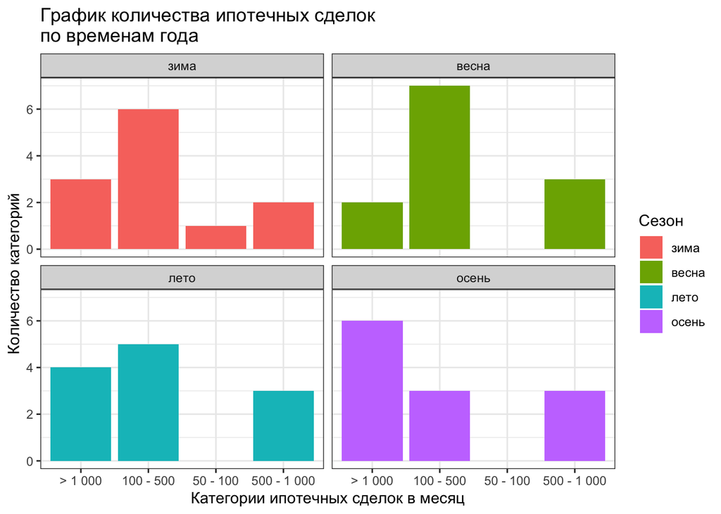

   Из графика видно, что минимальное количество ипотечных сделок приходиться на зиму, а максимальное на осень.
9. Построим график boxplot для распределения доли онлайн заявок в зависимости от времени года.

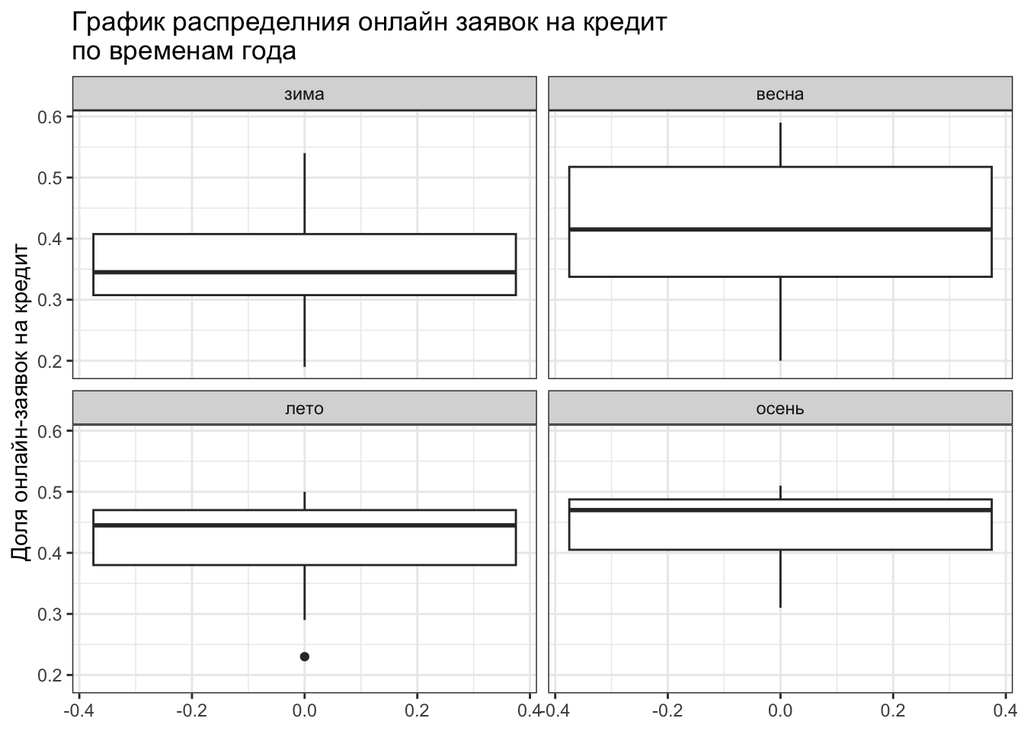

Что бы понять из данного графика в какое время года совершается наибольшее количество онлайн-заявок необходимо сравнить их медианы. Наибольшая медиана приходиться на осень и минимальная на зиму. Таким образом наибольшие количество онлайн заявок приходиться на осень, а минимальное на зиму. Увеличения онлайн заявок осенью, объясняется тем, что люди набирают кредитов в преддверии нового года (на подарки или, что-то для себя, дома) сервис сейчас очень распространен и пользоваться ими очень удобно. Касательно зимнего периода, предположу, что согласно графику движения туристов, в зимний период было увеличения туристов соответственно большинство людей поехали отдыхать. Оформление туристических путевок происходит в офисах компаний, где очень часто находятся представители банков, соответственно оформление кредита происходит в офлайн режиме.

10. Проверим гипотезу, есть ли связь между временем года и долей онлайн-заявок на кредит. Так как в сравниваемых данных присутствуют категориальные данные воспользуемся тестом хи-квадрат. Сформулируем нулевую гипотезу: зависимости между онлайн-заявками на кредит и временем года нет. Альтернативная гипотеза: зависимость есть. Уровень значимости 5%.

```
##
##  Pearson's Chi-squared test
##
## data:  df_final$`Онлайн-заявки` and df_final$Сезон
## X-squared = 88, df = 78, p-value = 0.2056
```

По результатом теста получили p-value = 0.21, что больше уровня значимости (5%), значит вероятность допустить ошибку отвергнув нулевую гипотезу более уровня значимости. Соответственно нет оснований отвергнуть нулевую гипотезу и зависимости между временем года и долей онлайн-заявками на кредит нет.

11. Построим график boxplot для распределения доли ипотечных сделок на вторичке в зависимости от сезона

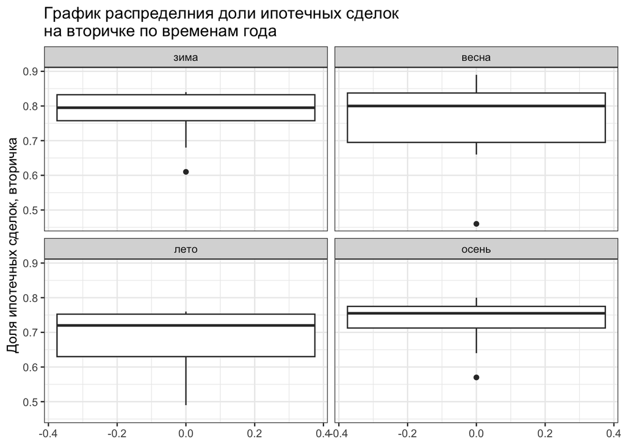

Что бы понять в какое время года ипотечных сделок на вторичное жилье было совершено больше на графике boxplot, необходимо сравнить их медианы. Согласно графику, время года в котором было совершено наибольшее количество сделок это зима и весна 2020 года, а минимальное это лето. Возможно это связанно с тем, что в летний период было сдано много нового жилья и люди предпочли брать ипотеки на новое жилье.

12. Проверим гипотезу, есть ли связь между временем года и долей ипотечных сделок на вторичное жилье. Также воспользуемся тестом хи-квадрат. Сформулируем нулевую и альтернативную гипотезу. Нулевая гипотеза: связи между долей ипотечный сделок на вторичном рынке и временем года нет. Альтернативная гтпотеза: связь есть. Уровень значимости 5%.

```
##
##  Pearson's Chi-squared test
##
## data:  df_final$`Доля сделок, вторичка` and df_final$Сезон
## X-squared = 78.667, df = 72, p-value = 0.2761
```

По результатам теста p-value = 0.27. Это значение больше уровня значимости. Вероятность допустить ошибку отвергнув нулевую гипотезу более уровня значимости. Основания отвергнуть нулевую гипотезу нет, соответственно связи между долей ипотечных сделок на вторичке и временем года нет.

13. Подводя итоги о проделанных изысканий относительно взятых людьми кредитов и ипотеки за 2020 год относительно сезона, можно сделать следующие выводы:
- максимальное количество ипотечных сделок приходилось на осень, а минимальное на зиму.
- из них максимальное количество сделок на вторичном рынке было сделано зимой и весной.
- что касается кредитов, то максимальное количество онлайн заявок на кредит за 2020 год было сделано осенью, а минимальное зимой.
- все эти данные актуальны на 2020 год, проведенные тесты показали, что каких-то взаимосвязей между ними и временем года нет. Возможно, что бы определить взаимосвязи необходимо больше данных (например взять набор данных за несколько лет) и произвести дополнительные изыскания и тесты.